# R Notebook

Integrantes: - Matías Donoso - Sergio Morales - Diego Ruiz

### Configuración inicial y carga de dataset

Se configura el entorno de trabajo para poder cargar el dataset

```r
setwd("C:/Users/Diego/Documents/Bibliografia2021-2/IntroALaMineria/Proyecto")
getwd()
```

Se carga el dataset .csv en un dataframe

```r
getwd()
```

```
[1] "/Users/catalaxis/Documents/Minerai de datos/proyecto-cc5206-main"
```

```r
tabla <- read.csv("datos/mineduc/rendimiento_escolar/2020.csv", as.is = FALSE, sep = ";", dec = ",")
```

### Exploración básica

1. ¿Cuáles son las dimensiones del dataset (filas, columnas)?.

```r
getwd()
```

```
[1] "/Users/catalaxis/Documents/Minerai de datos/proyecto-cc5206-main"
```

```r
dim(tabla)
```

```
[1] 3164534      37
```

2. ¿Qué describe cada línea del dataset?

```r
str(tabla)
```

```
'data.frame':   3164534 obs. of  37 variables:
 $ AGNO          : int  2020 2020 2020 2020 2020 2020 2020 2020 2020 2020 ...
 $ RBD           : int  1 1 1 1 1 1 1 1 1 1 ...
 $ DGV_RBD       : int  9 9 9 9 9 9 9 9 9 9 ...
 $ NOM_RBD       : Factor w/ 8338 levels "ABRAHAM LINCOLN MEMORIAL COLLEGE",..: 7930 7930 7930 7930 7930 7930 7930 7930 7930 7930 ...
 $ COD_REG_RBD   : int  15 15 15 15 15 15 15 15 15 15 ...
 $ NOM_REG_RBD_A : Factor w/ 16 levels "ANTOF","ARAUC",..: 4 4 4 4 4 4 4 4 4 4 ...
 $ COD_PRO_RBD   : int  151 151 151 151 151 151 151 151 151 151 ...
 $ COD_COM_RBD   : int  15101 15101 15101 15101 15101 15101 15101 15101 15101 15101 ...
 $ NOM_COM_RBD   : Factor w/ 345 levels "ALGARROBO","ALHUÉ",..: 12 12 12 12 12 12 12 12 12 12 ...
 $ COD_DEPROV_RBD: int  151 151 151 151 151 151 151 151 151 151 ...
 $ NOM_DEPROV_RBD: Factor w/ 42 levels "ANTOFAGASTA - TOCOPILLA",..: 3 3 3 3 3 3 3 3 3 3 ...
 $ COD_DEPE      : int  6 6 6 6 6 6 6 6 6 6 ...
 $ COD_DEPE2     : int  5 5 5 5 5 5 5 5 5 5 ...
 $ RURAL_RBD     : int  0 0 0 0 0 0 0 0 0 0 ...
```

[output cut: 23 more lines]

## Estadísticas resumen del dataset

```r
summary(tabla)
```

```
      AGNO           RBD           DGV_RBD
 Min.   :2020   Min.   :    1   Min.   :0.000
 1st Qu.:2020   1st Qu.: 4630   1st Qu.:2.000
 Median :2020   Median : 9810   Median :4.000
 Mean   :2020   Mean   :11656   Mean   :4.453
 3rd Qu.:2020   3rd Qu.:16634   3rd Qu.:7.000
 Max.   :2020   Max.   :41807   Max.   :9.000

                      NOM_RBD         COD_REG_RBD     NOM_REG_RBD_A
 ESCUELA ESPANA           :   5964   Min.   : 1.000   RM     :1213896
 ESCUELA GABRIELA MISTRAL :   5399   1st Qu.: 6.000   VALPO  : 320846
 COLEGIO SAN JOSE         :   5071   Median :10.000   BBIO   : 276417
 COLEGIO SAN IGNACIO      :   4863   Mean   : 9.458   MAULE  : 190252
 COLEGIO DARIO SALAS      :   4594   3rd Qu.:13.000   ARAUC  : 184490
 COLEGIO LEONARDO DA VINCI:   4309   Max.   :16.000   LGBO   : 169713
 (Other)                  :3134334                    (Other): 808920
  COD_PRO_RBD     COD_COM_RBD         NOM_COM_RBD      COD_DEPROV_RBD
 Min.   : 11.0   Min.   : 1101   PUENTE ALTO:  94860   Min.   : 11.00
 1st Qu.: 61.0   1st Qu.: 6108   MAIPÚ      :  86580   1st Qu.: 61.00
 Median :101.0   Median :10101   SANTIAGO   :  78530   Median : 93.00
 Mean   : 96.5   Mean   : 9657   ANTOFAGASTA:  70326   Mean   : 95.15
 3rd Qu.:131.0   3rd Qu.:13122   LA FLORIDA :  67802   3rd Qu.:134.00
 Max.   :163.0   Max.   :16305   TEMUCO     :  59422   Max.   :151.00
                                 (Other)    :2707014
           NOM_DEPROV_RBD       COD_DEPE       COD_DEPE2       RURAL_RBD
 SANTIAGO PONIENTE: 219411   Min.   :1.000   Min.   :1.000   Min.   :0.0000
 SANTIAGO ORIENTE : 209317   1st Qu.:2.000   1st Qu.:1.000   1st Qu.:0.0000
 CORDILLERA       : 199300   Median :3.000   Median :2.000   Median :0.0000
 SANTIAGO SUR     : 189527   Mean   :2.756   Mean   :1.872   Mean   :0.0765
 VALPARAÍSO       : 175961   3rd Qu.:3.000   3rd Qu.:2.000   3rd Qu.:0.0000
 SANTIAGO NORTE   : 174838   Max.   :6.000   Max.   :5.000   Max.   :1.0000
 (Other)          :1996180
  ESTADO_ESTAB      COD_ENSE       COD_ENSE2       COD_GRADO
 Min.   :1.000   Min.   :110.0   Min.   :2.000   Min.   :1.00
 1st Qu.:1.000   1st Qu.:110.0   1st Qu.:2.000   1st Qu.:2.00
 Median :1.000   Median :110.0   Median :2.000   Median :3.00
 Mean   :1.001   Mean   :196.9   Mean   :3.215   Mean   :3.78
 3rd Qu.:1.000   3rd Qu.:310.0   3rd Qu.:5.000   3rd Qu.:5.00
 Max.   :3.000   Max.   :910.0   Max.   :8.000   Max.   :8.00

```

[output cut: 24 more lines]

```
    COD_SEC          COD_ESPE       PROM_GRAL       ASISTENCIA     SIT_FIN
 Min.   :  0.00   Min.   :    0   Min.   :0.000   Min.   :  0.00    :   1226
 1st Qu.:  0.00   1st Qu.:    0   1st Qu.:5.400   1st Qu.: 85.00   P:2990234
 Median :  0.00   Median :    0   Median :6.200   Median : 96.00   R:  58664
 Mean   : 29.13   Mean   : 2914   Mean   :5.777   Mean   : 89.51   Y: 114410
 3rd Qu.:  0.00   3rd Qu.:    0   3rd Qu.:6.700   3rd Qu.:100.00
 Max.   :910.00   Max.   :91005   Max.   :7.000   Max.   :100.00

 SIT_FIN_R      COD_MEN
  :   1197   Min.   :       0
 P:2990234   1st Qu.:       0
 R:  58587   Median :       0
 T:  82755   Mean   : 1249938
 Y:  31761   3rd Qu.:       0
             Max.   :72007004
```

Del sumario anterior se obtiene la siguiente información:

- Hay 3164534 estudiantes en esta base de datos
- La escuela con un mayor número de alumnos registrados es la Escuela España con 5964 estudiantes
- El código de región varía entre 1 y 16, luego todas las regiones son representadas en este dataset
- Las regiones con más representación en termino de estudiantes son RM :1213896  
  Valparaiso : 320846  
  BioBio : 276417  
  Maule : 190252  
  Araucania : 184490  
  LGBO : 169713 (Libertador General Bernardo O’Higgins)
- Las comunas con el mayor número de estudiantes son: NOM_COD_RBD Puente Alto : 94860  
  Maipú : 86580  
  Santiago : 78530  
  Antofagasta : 70326  
  La Florida : 67802  
  Temuco : 59422
- Las provincias con más representación en término del número de estudiantes son : NO_DEPROV_RBD Santiago Poniente : 219411  
  Santiago Oriente : 209317  
  Cordillera : 199300  
  Santiago Sur : 189527  
  Valparaiso : 175961  
  Santiago Norte : 174838
- Comunas con mayor número de estudiantes residentes son: NOM_COM_ALU Puente Alto : 106080  
  Maipú : 91020  
  Antofagasta : 74512  
  La Florida : 63181  
  San Bernardo : 58906  
  Viña Del Mar : 55713
- El promedio del promedio general es un 5,7 y la mediana es un 6.2, el 50% de los alumnos tiene un promedio general entre 5.4 y 6.7
- La asistencia promedio es de 89.51%, la mediana es un 96% y el 50% de los alumnos tiene una asistencia entre 85% y 100%

El 94,4% de los estudiantes es promovido El 1,8% de los estudiantes es reprobado El 1% de los estudiantes es retirado El 2,61% de los estudiantes son trasladados

### Representatividad de todo Chile a través de dataset

## Provincias

```r
length(unique(tabla$COD_PRO_RBD))
```

```
[1] 56
```

De una fuente externa a este dataset se obtiene que Chile cuenta con 56 provincias, luego se concluye que toda provincia está representada en este dataset.

## Comunas

```r
length(unique(tabla$COD_COM_RBD))
```

```
[1] 345
```

El dataset representa 345 comunas, Chile tiene 346 comunas, luego solo una comuna del país no cuenta con establecimientos educacionales representados

## Establecimientos educacionales

```r
length(unique(tabla$RBD))
```

```
[1] 9040
```

De una fuente externa a este dataset se obtiene que Chile cuenta con alrededor de 12000 establecimientos educacionales, de los cuales 9040 se ven representados en este dataset

### Relacion entre variables y la asistencia y promedio general

## Relacion a la región del estudiante

Se realiza agregación del dataset según el atributo NOM_REG_RBD_A, nombre de la región del estudio

```r
library(tidyverse)
grupos_region <- tabla %>% group_by(NOM_REG_RBD_A)
```

# Promedio general por region

Luego se obtiene el promedio general para cada región y se ordena de manera descendiente

```r
promreg <- grupos_region %>% summarise(
  prom = mean(PROM_GRAL)
)
promreg[order(promreg$prom, decreasing = TRUE),]
```

| NOM_REG_RBD_A | prom |
| --- | --- |
| MAG | 6.005550 |
| BBIO | 5.911038 |
| AYSEN | 5.882116 |
| MAULE | 5.862443 |
| NUBLE | 5.861416 |
| ATCMA | 5.849920 |
| COQ | 5.812368 |
| AYP | 5.805953 |
| TPCA | 5.780155 |
| ANTOF | 5.767463 |

[output cut: 6 more lines]

Con lo cual observamos que la región con el mayor promedio general es la Región de Magallanes con un 6.0 mientras que región con menor promedio general es la Región de Los Lagos con 5.7

# Asistencia por región

Se obtiene el promedio de asistencia por región y se ordena de manera descendiente

```r
asistreg <- grupos_region %>% summarise(
  asist = mean(ASISTENCIA)
)
asistreg[order(asistreg$asist, decreasing = TRUE),]
```

| NOM_REG_RBD_A | asist |
| --- | --- |
| AYSEN | 92.64307 |
| MAULE | 92.61140 |
| ARAUC | 91.80592 |
| LGBO | 91.05891 |
| RIOS | 91.05517 |
| COQ | 90.83337 |
| TPCA | 90.83020 |
| NUBLE | 90.75230 |
| BBIO | 90.66053 |
| VALPO | 89.86629 |

[output cut: 6 more lines]

## Relacion al establecimiento al cual asiste el estudiante

Se realiza agregación del dataset según el atributo NOM_RBD, nombre del colegio al cual asiste el estudiante

```r
grupos_establecimiento <- tabla %>% group_by(NOM_RBD)
```

# Promedio general por establecimiento educacional

Luego se obtiene el promedio general para cada establecimiento educacional y se ordena de manera descendiente

```r
promcol <- grupos_establecimiento %>% summarise(
  prom = mean(PROM_GRAL)
)
promcol[order(promcol$prom, decreasing = TRUE),]
```

| NOM_RBD | prom |
| --- | --- |
| ESCUELA NAHUELBUTA ALTO | 7.000000 |
| ESCUELA RURAL EL PEUCHEN | 7.000000 |
| ESCUELA SAN ERNESTO | 7.000000 |
| ESCUELA VERGARA | 6.975000 |
| ESCUELA MUNICIPAL PASO DEL SOLDADO | 6.950000 |
| COLEGIO RAUQUEN | 6.901884 |
| ESC.PDTE.FEDERICO ERRAZURIZ ECHAURREN | 6.900000 |
| ESCUELA MANANTIALES | 6.900000 |
| ESCUELA RURAL LINEA SOLAR | 6.900000 |
| ESCUELA RURAL QUILAR | 6.900000 |

[output cut: 990 more lines]

```r
NA
```

Mediante un scatter plot, se visualiza la distribucion de promedios por colegio

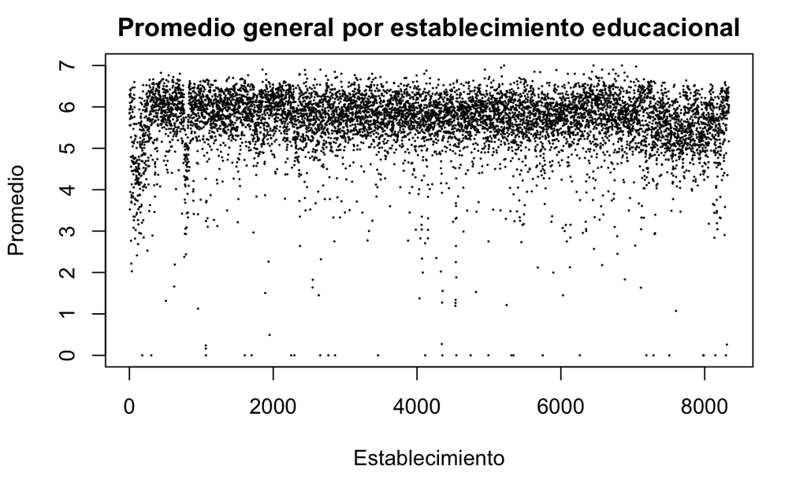

```r
plot(promcol$prom, main="Promedio general por establecimiento educacional", xlab="Establecimiento", ylab="Promedio", type = "p", cex = 0.1)
```

Al visualizar el scatter plot anterior se observa la presencia de datos faltantes en forma de promedio 0 para ciertos colegios. Los cuales seran extraídos.

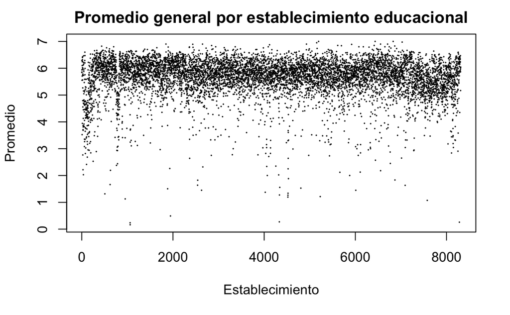

```r
promcolnooutliers<-promcol[promcol$prom>0,]
plot(promcolnooutliers$prom, main="Promedio general por establecimiento educacional", xlab="Establecimiento", ylab="Promedio", type = "p", cex = 0.1)
```

De esta forma la información se puede estudiar de forma más expedita.